# Matching tree and data

Rosana Zenil-Ferguson

2025-09-25

## Matching tree and data

One of the hardest things to do is to match phylogenetic trees with data. There is a lot of potential problems when we do this.

Let’s start with an example from Sabath et al. (2015) and colleagues about sexual systems in plants. For this we are going to need some basic libraries.

```r
library(ape)
library(phytools)
library(ggtree)
```

```r
library(ggplot2)
library(treeplyr)
```

## Check your tree

A good practice is always to open your kind of tree format you have and then call the appropriate function. For example use `read.newick()` or `read.nexus()`

```r
angiosperm.tree<-readNexus("janssens2020.tre")
```

Questions

1. How big is this tree?
2. Is it ultrametric (`is.ultrametric()`)?
3. Is it binary (`is.binary()`)?

## Quick plot for tree

```r
plot(angiosperm.tree, type="fan", cex=0.02)
```

[output not shown]

```r
sexualsystem.dataset<-read.csv("sexual.system.classifications.csv",header=TRUE)
```

1. Check what is inside this dataset using the function `head()`
2. Use `dim()` to see how many rows and columns your dataset has. Does it match the tips on the phylogeny?

```r
matched<-make.treedata(angiosperm.tree,sexualsystem.dataset,name_column = 1)
```

Explored what the `matched` object has print it and use the function `str()`. What is happening here?

# Plot the tree with tip points colored by trait

```r
## First we create a dataset with our matches
## In the first column we are going to re-add the names of the species (taxa) so we know how to check for errors in the future

trait.dataset= as.data.frame(cbind(species=matched$phy$tip.label,matched$dat))

# Okay now let's do a fancy plot!

p <- ggtree(matched$phy, layout="circular") %<+% trait.dataset +  # %<+% joins data to the tree
  geom_tippoint(aes(color = strict), size = 1) +
  theme_tree2() +
  ggtitle("Sexual Systems (strict)")
```

## Transforming the data to plot it correctly

In order to plot this correctly with the colors that we want we need to convert these data to discrete categories. We do this with this option

```r
discrete.strict= as.factor(matched$dat$strict)

#and we add our new column to the dataset. Notice that I never delete data or replace one column for another

trait.dataset= cbind(trait.dataset, discrete.strict)
```

Now we can plot using colors that we like

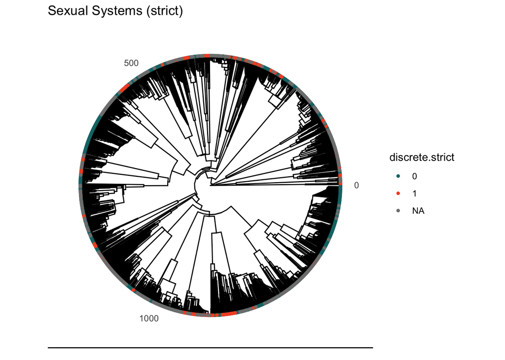

```r
p <- ggtree(matched$phy, layout="circular") %<+% trait.dataset +  # This weird function %<+% joins data to the tree
  geom_tippoint(aes(color = discrete.strict), size = 1) +
  theme_tree2() +
  ggtitle("Sexual Systems (strict)")+
  scale_color_manual(values = c("0" = "#127475",
                                "1" = "#F2542D"))
print(p)
```

## Try on your own

There is a bunch of trees and datasets in the files that I just sent to you. Try your hand at transforming the data plotting it with new colors and be creative!